# Clustering - Electricity Demand (Unsupervised Learning)

## Description

Studying the electric demand of clients in Portugal during 2013 and 2014.

The data contains 370 time series, corresponding to the electric demand for 370 clients, between 2011 and 2014.

#### Data:

https://archive.ics.uci.edu/ml/datasets/ElectricityLoadDiagrams20112014#

## Data Preparation

```python
pathToFile = r"C:\Users\willjdsouza\Desktop\github\"
fileName = '\LD2011_2014.txt'
```

```python
import numpy as np
from sklearn.cluster import KMeans
import matplotlib.pyplot as plt
import random
from sklearn.metrics import silhouette_score
from sklearn.cluster import AgglomerativeClustering
random.seed(42)
```

```python
# Replace "," by ".", so numbers will be in the form 2.3 instead of 2,3
import fileinput

with fileinput.FileInput(pathToFile+fileName, inplace=True, backup='.bak') as file:
    for line in file:
        print(line.replace(",", "."), end='')
```

```python
# Creating dataframe
import pandas as pd
data = pd.read_csv(pathToFile+fileName, sep=";", index_col=0)
```

### Quick data inspection

```python
data.head(2)
```

|  | MT_001 | MT_002 | MT_003 | MT_004 | MT_005 | MT_006 | MT_007 | MT_008 | MT_009 | MT_010 | ... | MT_361 | MT_362 | MT_363 | MT_364 | MT_365 | MT_366 | MT_367 | MT_368 | MT_369 | MT_370 |
| --- | --- | --- | --- | --- | --- | --- | --- | --- | --- | --- | --- | --- | --- | --- | --- | --- | --- | --- | --- | --- | --- |
| 2011-01-01 00:15:00 | 0.0 | 0.0 | 0.0 | 0.0 | 0.0 | 0.0 | 0.0 | 0.0 | 0.0 | 0.0 | ... | 0.0 | 0.0 | 0.0 | 0.0 | 0.0 | 0.0 | 0.0 | 0.0 | 0.0 | 0.0 |
| 2011-01-01 00:30:00 | 0.0 | 0.0 | 0.0 | 0.0 | 0.0 | 0.0 | 0.0 | 0.0 | 0.0 | 0.0 | ... | 0.0 | 0.0 | 0.0 | 0.0 | 0.0 | 0.0 | 0.0 | 0.0 | 0.0 | 0.0 |

2 rows × 370 columns

```python
data.tail(2)
```

|  | MT_001 | MT_002 | MT_003 | MT_004 | MT_005 | MT_006 | MT_007 | MT_008 | MT_009 | MT_010 | ... | MT_361 | MT_362 | MT_363 | MT_364 | MT_365 | MT_366 | MT_367 | MT_368 | MT_369 | MT_370 |
| --- | --- | --- | --- | --- | --- | --- | --- | --- | --- | --- | --- | --- | --- | --- | --- | --- | --- | --- | --- | --- | --- |
| 2014-12-31 23:45:00 | 1.269036 | 21.337127 | 1.737619 | 166.666667 | 85.365854 | 285.714286 | 10.17524 | 225.589226 | 64.685315 | 72.043011 | ... | 246.252677 | 28000.0 | 1443.037975 | 909.090909 | 26.075619 | 4.095963 | 664.618086 | 146.911519 | 646.627566 | 6540.540541 |
| 2015-01-01 00:00:00 | 2.538071 | 19.914651 | 1.737619 | 178.861789 | 84.146341 | 279.761905 | 10.17524 | 249.158249 | 62.937063 | 69.892473 | ... | 188.436831 | 27800.0 | 1409.282700 | 954.545455 | 27.379400 | 4.095963 | 628.621598 | 131.886477 | 673.020528 | 7135.135135 |

2 rows × 370 columns

```python
data.shape
```

```
(140256, 370)
```

#### The dataframe contains a row for each interval of 15 minutes between Jan 1, 2011 to Dec 31 2014. There are 370 columns (370 clients). The dataframe is indexed by a timestamp.

- Frequency is 15 minutes, each day provides 24 x 4 = 96 datapoints
- 96 multiplied by 365 days and 4 years (plus 1 day in Feb 29, 2012) gives: 96 x 365 x 4 + 96 = 140256 (seen in data.shape)

```python
data.info()
```

```
<class 'pandas.core.frame.DataFrame'>
Index: 140256 entries, 2011-01-01 00:15:00 to 2015-01-01 00:00:00
Columns: 370 entries, MT_001 to MT_370
dtypes: float64(370)
memory usage: 397.0+ MB
```

```python
data.describe()
```

|  | MT_001 | MT_002 | MT_003 | MT_004 | MT_005 | MT_006 | MT_007 | MT_008 | MT_009 | MT_010 | ... | MT_361 | MT_362 | MT_363 | MT_364 | MT_365 | MT_366 | MT_367 | MT_368 | MT_369 | MT_370 |
| --- | --- | --- | --- | --- | --- | --- | --- | --- | --- | --- | --- | --- | --- | --- | --- | --- | --- | --- | --- | --- | --- |
| count | 140256.000000 | 140256.000000 | 140256.000000 | 140256.000000 | 140256.000000 | 140256.000000 | 140256.000000 | 140256.000000 | 140256.000000 | 140256.000000 | ... | 140256.000000 | 140256.000000 | 140256.000000 | 140256.000000 | 140256.000000 | 140256.000000 | 140256.000000 | 140256.000000 | 140256.000000 | 140256.000000 |
| mean | 3.970785 | 20.768480 | 2.918308 | 82.184490 | 37.240309 | 141.227385 | 4.521338 | 191.401476 | 39.975354 | 42.205152 | ... | 218.213701 | 37607.987537 | 1887.427366 | 2940.031734 | 65.413150 | 9.269709 | 424.262904 | 94.704717 | 625.251734 | 8722.355145 |
| std | 5.983965 | 13.272415 | 11.014456 | 58.248392 | 26.461327 | 98.439984 | 6.485684 | 121.981187 | 29.814595 | 33.401251 | ... | 204.833532 | 38691.954832 | 1801.486488 | 2732.251967 | 65.007818 | 10.016782 | 274.337122 | 80.297301 | 380.656042 | 9195.155777 |
| min | 0.000000 | 0.000000 | 0.000000 | 0.000000 | 0.000000 | 0.000000 | 0.000000 | 0.000000 | 0.000000 | 0.000000 | ... | 0.000000 | 0.000000 | 0.000000 | 0.000000 | 0.000000 | 0.000000 | 0.000000 | 0.000000 | 0.000000 | 0.000000 |
| 25% | 0.000000 | 2.844950 | 0.000000 | 36.585366 | 15.853659 | 71.428571 | 0.565291 | 111.111111 | 13.986014 | 9.677419 | ... | 5.710207 | 0.000000 | 0.000000 | 0.000000 | 13.037810 | 0.000000 | 0.000000 | 30.050083 | 83.944282 | 0.000000 |
| 50% | 1.269036 | 24.893314 | 1.737619 | 87.398374 | 39.024390 | 157.738095 | 2.826456 | 222.222222 | 40.209790 | 40.860215 | ... | 131.334761 | 24100.000000 | 1050.632911 | 2136.363636 | 31.290743 | 7.021650 | 525.899912 | 76.794658 | 758.064516 | 0.000000 |
| 75% | 2.538071 | 29.871977 | 1.737619 | 115.853659 | 54.878049 | 205.357143 | 4.522329 | 279.461279 | 57.692308 | 61.290323 | ... | 403.283369 | 54800.000000 | 3312.236287 | 5363.636364 | 108.213820 | 11.702750 | 627.743635 | 151.919866 | 875.366569 | 17783.783784 |
| max | 48.223350 | 115.220484 | 151.172893 | 321.138211 | 150.000000 | 535.714286 | 44.657999 | 552.188552 | 157.342657 | 198.924731 | ... | 852.962170 | 192800.000000 | 7751.054852 | 12386.363636 | 335.071708 | 60.269163 | 1138.718174 | 362.270451 | 1549.120235 | 30918.918919 |

8 rows × 370 columns

### Plotting first 2 days of 2012 for the first 2 clients

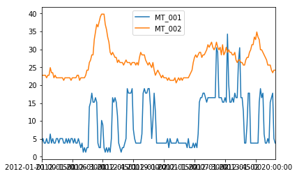

```python
data_example = data.loc['2012-01-01 00:15:00':'2012-01-03 00:00:00'][['MT_001','MT_002']]
data_example.plot()
plt.show()
```

#### Main difference between the curves is the level, so we know we will have to somehow normalize the curves for the clustering technique to capture the behaviour throughout the day, rather than the overall level.

### Data analysis

Focusing on 2013 and 2014 because these are the years with lower number of clients having zero demand

```python
data2011 = data.loc['2011-01-01 00:15:00':'2012-01-01 00:00:00']
data2012 = data.loc['2012-01-01 00:15:00':'2013-01-01 00:00:00']
data2013 = data.loc['2013-01-01 00:15:00':'2014-01-01 00:00:00']
data2014 = data.loc['2014-01-01 00:15:00':'2015-01-01 00:00:00']
```

```python
# Check number of days
print(data2011.shape[0]/96)
print(data2012.shape[0]/96)
print(data2013.shape[0]/96)
print(data2014.shape[0]/96)
```

```
365.0
366.0
365.0
365.0
```

```python
# See number of clients with 0 demand per year
print(sum(data2011.mean()==0))
print(sum(data2012.mean()==0))
print(sum(data2013.mean()==0))
print(sum(data2014.mean()==0))
```

```
210
37
21
1
```

```python
clients = data2011.columns
clients_no_demand = clients[data2013.mean()==0] # clients with 0 demand
data_13_14 = data2013.append(data2014) # appending 2013 and 2014
data_13_14 = data_13_14.drop(clients_no_demand, axis=1) # drop clients with 0 demand
print(data_13_14.shape)
print(sum(data_13_14.mean()==0)) # check that there are no clients with 0 demand
```

```
(70080, 349)
0
```

## Getting average curves per client

```python
data = data_13_14.copy() # weekdays weekends, data2011, data2012, data2013, data2014
```

```python
data['hour'] = data.index.map(lambda x: x[11:])
```

```python
data.head(3)
```

|  | MT_001 | MT_002 | MT_003 | MT_004 | MT_005 | MT_006 | MT_007 | MT_008 | MT_009 | MT_010 | ... | MT_362 | MT_363 | MT_364 | MT_365 | MT_366 | MT_367 | MT_368 | MT_369 | MT_370 | hour |
| --- | --- | --- | --- | --- | --- | --- | --- | --- | --- | --- | --- | --- | --- | --- | --- | --- | --- | --- | --- | --- | --- |
| 2013-01-01 00:15:00 | 2.538071 | 22.759602 | 2.606429 | 138.211382 | 63.414634 | 255.952381 | 4.522329 | 239.057239 | 57.692308 | 78.494624 | ... | 22300.0 | 886.075949 | 1000.000000 | 16.949153 | 6.436513 | 616.330114 | 76.794658 | 731.671554 | 8086.486486 | 00:15:00 |
| 2013-01-01 00:30:00 | 1.269036 | 22.759602 | 2.606429 | 138.211382 | 63.414634 | 264.880952 | 5.652911 | 228.956229 | 57.692308 | 76.344086 | ... | 21000.0 | 864.978903 | 909.090909 | 18.252934 | 3.510825 | 564.530290 | 76.794658 | 727.272727 | 8086.486486 | 00:30:00 |
| 2013-01-01 00:45:00 | 2.538071 | 22.759602 | 2.606429 | 134.146341 | 60.975610 | 250.000000 | 5.652911 | 239.057239 | 54.195804 | 76.344086 | ... | 18200.0 | 860.759494 | 840.909091 | 16.949153 | 5.851375 | 590.869183 | 68.447412 | 730.205279 | 7848.648649 | 00:45:00 |

3 rows × 350 columns

### Getting average curves per client

```python
datagrouped = data.groupby("hour")
average_curves = datagrouped.agg("mean")
average_curves.shape
```

```
(96, 349)
```

#### Dividing each curve by its mean, so that all curves have mean 1

```python
average_curves_norm = average_curves/(average_curves.mean())
```

#### Plotting first 2 and last 2 clients

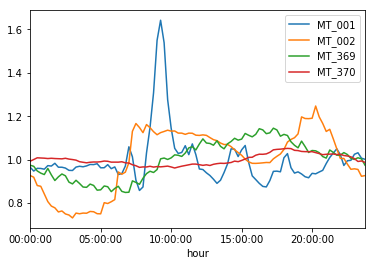

```python
average_curves_norm[['MT_001','MT_002','MT_369','MT_370']].plot()
plt.show()
```

## Clustering Analysis

I created two models, one for k means and one for the agglomerative clustering model. I plotted inertia1, inertia2 and silhoutte for k means. For the agglomerative clustering model I plotted the silhoutte score. This in essence will find the optimal number of clusters

In terms of the agglomerative clustering model, the optimal number of clusters seems to be at 5, we can see this again at the highest point in the graph

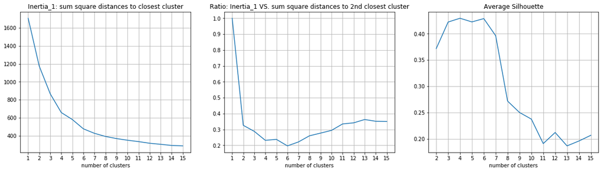

```python
inertias_1 = []
inertias_2 = []
silhouette_avgs = []
max_K = 15
for k in np.arange(1,max_K+1):
    kmeans = KMeans(n_clusters=k, random_state=0).fit(X)
    inertias_1 = inertias_1 + [kmeans.inertia_]
    inertias_2 = inertias_2 + [getInertia2(X,kmeans)]
    if k>1:
        silhouette_avgs = silhouette_avgs + [silhouette_score(X, kmeans.labels_)]

plt.figure(figsize=(20,5))

plt.subplot(1,3,1)
plt.title("Inertia_1: sum square distances to closest cluster")
plt.plot(np.arange(1,max_K+1),inertias_1)
plt.xticks(np.arange(1,max_K+1))
plt.xlabel('number of clusters')
plt.grid()

plt.subplot(1,3,2)
plt.title("Ratio: Inertia_1 VS. sum square distances to 2nd closest cluster")
plt.plot(np.arange(1,max_K+1),np.array(inertias_1)/np.array(inertias_2))
plt.xticks(np.arange(1,max_K+1))
plt.xlabel('number of clusters')
plt.grid()

plt.subplot(1,3,3)
plt.title("Average Silhouette")
plt.plot(np.arange(2,max_K+1), silhouette_avgs)
plt.xticks(np.arange(2,max_K+1))
plt.xlabel('number of clusters')
plt.grid()

plt.show()
```

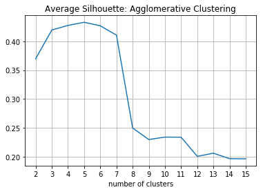

```python
silhouette_avgs = []
max_K = 15
for k in np.arange(1,max_K+1):
    agg_c = AgglomerativeClustering(n_clusters=k).fit(X)
    if k>1:
        silhouette_avgs = silhouette_avgs + [silhouette_score(X, agg_c.labels_)]

plt.plot(np.arange(2,max_K+1), silhouette_avgs)
plt.title("Average Silhouette: Agglomerative Clustering")
plt.xticks(np.arange(2,max_K+1))
plt.xlabel('number of clusters')
plt.grid()

plt.show()
```

I plotted 2 graphs for the k means model, the curves for all the clusters because I could segment the curves to each cluster, and the centroid curve as well. However, for the agglomerative clustering model, I was only able to get the curves that belond to each cluster. Since I wasn't able to get the coordinates for the centroids, it was difficult for me to be able to plot this.

#### Kmeans Model

```python
kmeans = KMeans(n_clusters=6, random_state = 42)
kmeans = kmeans.fit(X)
kmeans_labels = kmeans.labels_   #obtaining labels for clusters
kmeans_centers = kmeans.cluster_centers_   #obtaining centroid curves for data
data_clustered = pd.DataFrame(X.T, columns = kmeans_labels)   #putting it back into a dataframe to plot with the labels
centroid_curves = pd.DataFrame(kmeans_centers.T)   #putting it back into a dataframe to plot the centroids

print("The number of clients in each cluster are...")
print("Cluster 1:", (kmeans_labels == 0).sum())
print("Cluster 2:", (kmeans_labels == 1).sum())
print("Cluster 3:", (kmeans_labels == 2).sum())
print("Cluster 4:", (kmeans_labels == 3).sum())
print("Cluster 5:", (kmeans_labels == 4).sum())
print("Cluster 6:", (kmeans_labels == 5).sum())
```

```
The number of clients in each cluster are...
Cluster 1: 35
Cluster 2: 199
Cluster 3: 79
Cluster 4: 4
Cluster 5: 31
Cluster 6: 1
```

#### Agglomerative Clustering Model

```python
AGC = AgglomerativeClustering(n_clusters = 5)
AGC = AGC.fit(X)
AGC_labels = AGC.labels_
AGC_clustered = pd.DataFrame(X.T, columns = AGC_labels)

print("The number of clients in each cluster are...")
print("Cluster 1:", (AGC_labels == 0).sum())
print("Cluster 2:", (AGC_labels == 1).sum())
print("Cluster 3:", (AGC_labels == 2).sum())
print("Cluster 4:", (AGC_labels == 3).sum())
print("Cluster 5:", (AGC_labels == 4).sum())
```

```
The number of clients in each cluster are...
Cluster 1: 109
Cluster 2: 35
Cluster 3: 200
Cluster 4: 4
Cluster 5: 1
```

The following code for the graphs has an x scale that differs a bit from the time signatures. It is represented in whole numbers, however we can easily translate it to the relvent hour if needed.

20 = 5 hours

4 = 1 hour

1 = 15 minutes

#### Kmeans Curves and Centroids

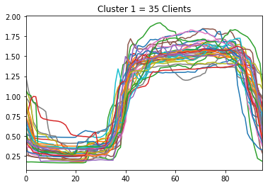

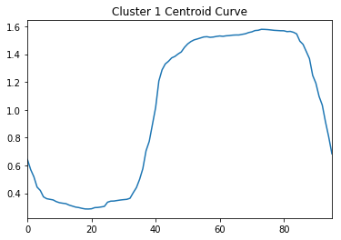

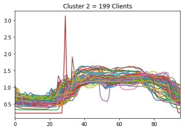

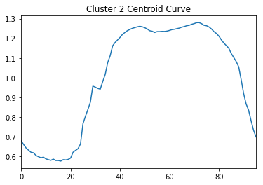

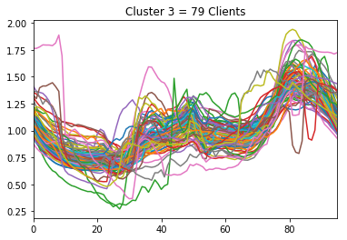

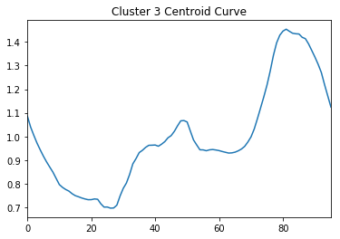

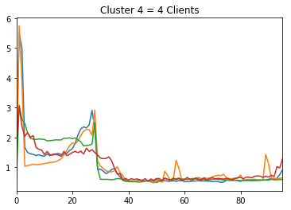

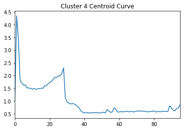

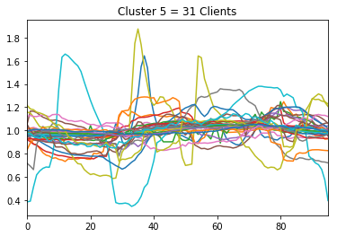

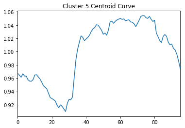

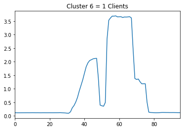

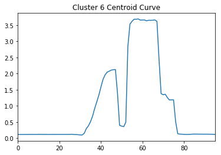

```python
data_clustered[0].plot(legend=None)
plt.title("Cluster 1 = 35 Clients")
plt.show()

centroid_curves[0].plot(legend=None)
plt.title("Cluster 1 Centroid Curve")
plt.show()

data_clustered[1].plot(legend=None)
plt.title("Cluster 2 = 199 Clients")
plt.show()

centroid_curves[1].plot(legend=None)
plt.title("Cluster 2 Centroid Curve")
plt.show()

data_clustered[2].plot(legend=None)
plt.title("Cluster 3 = 79 Clients")
plt.show()

centroid_curves[2].plot(legend=None)
plt.title("Cluster 3 Centroid Curve")
plt.show()

data_clustered[3].plot(legend=None)
plt.title("Cluster 4 = 4 Clients")
plt.show()

centroid_curves[3].plot(legend=None)
plt.title("Cluster 4 Centroid Curve")
plt.show()

data_clustered[4].plot(legend=None)
plt.title("Cluster 5 = 31 Clients")
plt.show()

centroid_curves[4].plot(legend=None)
plt.title("Cluster 5 Centroid Curve")
plt.show()

data_clustered[5].plot(legend=None)
plt.title("Cluster 6 = 1 Clients")
plt.show()

centroid_curves[5].plot(legend=None)
plt.title("Cluster 6 Centroid Curve")
plt.show()
```

#### Agglomerative Clustering Curves

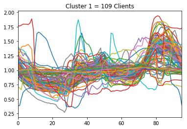

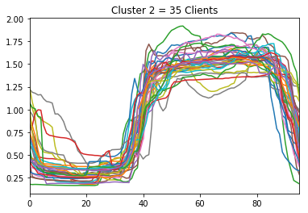

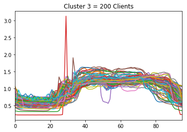

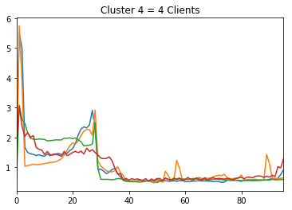

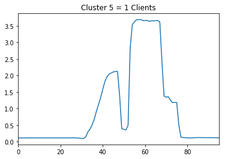

```python
AGC_clustered[0].plot(legend=None)
plt.title("Cluster 1 = 109 Clients")
plt.show()

AGC_clustered[1].plot(legend=None)
plt.title("Cluster 2 = 35 Clients")
plt.show()

AGC_clustered[2].plot(legend=None)
plt.title("Cluster 3 = 200 Clients")
plt.show()

AGC_clustered[3].plot(legend=None)
plt.title("Cluster 4 = 4 Clients")
plt.show()

AGC_clustered[4].plot(legend=None)
plt.title("Cluster 5 = 1 Clients")
plt.show()
```